# Heart Disease UCI

### Sumithra Hariguruprasad

Introducion

- Dataset Column Features
- Importing Libraries and Data
- Exploratory Data Analysis
  - Target
  - Age
  - Sex
  - Chest Pain Type
  - Fasting Blood sugar
  - Maximum Heart Rate
  - Thal
- Outliers
- Correlation
- Chi-Square
- Model
  - Logistic Regression Using Statsmodel
    - Model Summary
    - Confusion Matrix
    - ROC Curve
  - Logistic Regression Using Sklearn
    - Confusion Matrix
    - Classification Report
    - ROC Curve
  - Naive Bayes
    - Confusion Matrix
    - Classification Report
    - ROC Curve
- Summary

## Introduction

- Heart disease is also known as ischemic heart disease or coronary heart disease.It is the leading cause of death for people of most racial/ethnic groups in the United States and it is second only to cancer.According to Public Health Agency of Canada (PHAC), it is the 2nd leading cause of death in Canada.
- The early detection and management of medical conditions such as high blood pressure, diabetes and high cholesterol can help us in making decisions on lifestyle changes in high risk patients and in turn reduce the complications.
- Here we have the dataset which is a part of the Heart Disease Data Set (the part obtained from the V.A. Medical Center, Long Beach and Cleveland Clinic Foundation), using a subset of 14 attributes.
- The dataset contains many medical indicators, the goal is to predict the angiographic disease status of heart disease in column 14.
- The output is either Heart disease (0) or No Heart Disease (1).

### Dataset Column Features

There are 14 attributes used:

1. **age:** age in years
2. **sex:** sex (1 = male; 0 = female)
3. **cp:** chest pain type
   - Value 3: typical angina Typical angina, Chest pain related decrease blood supply to the heart
   - Value 1: atypical angina , Chest pain not related to heart
   - Value 2: non-anginal pain , Typically esophageal spasms (non heart related)
   - Value 0: asymptomatic, Chest pain not showing signs of disease
4. **trestbps:** resting blood pressure (in mm Hg on admission to the hospital)
   - Anything above 130-140 is typically cause for concern
5. **chol:** serum cholestoral in mg/dl
   - serum = LDL + HDL + .2 * triglycerides
   - Above 200 is cause for concern
6. **fbs:** (fasting blood sugar > 120 mg/dl) (1 = true; 0 = false)
   - fbs > 120 mg/dL signals diabetes
7. **restecg:** resting electrocardiographic results
   - Value 1: normal , Nothing to note
   - Value 2: having ST-T wave abnormality (T wave inversions and/or ST elevation or depression of > 0.05 mV)

     ```
     - Can range from mild symptoms to severe problems
     - Signals non-normal heart beat
     ```

   - Value 0: showing probable or definite left ventricular hypertrophy

     ```
     - Enlarged heart's main pumping chamber
     ```

8. **thalach:** maximum heart rate achieved,
   - Higher heart Rate is good
9. **exang:** exercise induced angina (1 = yes; 0 = no)
10. **oldpeak:** ST depression induced by exercise relative to rest
    - Look at stress of heart during excercise.Unhealthy heart will stress more
11. **slope:** the slope of the peak exercise ST segment
    - Value 2: upsloping ,Better heart rate with excercise (typical healthy heart)
    - Value 1: flat , Minimal change (start of unhealthy heart)
    - Value 0: downsloping, Signs of unhealthy heart
12. **ca:** number of major vessels (0-3) colored by flouroscopy
    - Colored vessel means the doctor can see the blood passing through Move blood movement the better (no clots), 0 means good
13. **thal:** Thalium stress test result, Sees how blood moves through your heart while exercising
    - Value 2: normal
    - Value 1: fixed defect, Used to be defect but now okay
    - Value 3: reversable defect,Not proper blood movement when excercising
    - Value 0 = missing values
14. **target:**: diagnosis of heart disease (angiographic disease status)
    - Value 1: No heart disease
    - Value 0: Heart disease

*Categorical Variables:* Sex, cp, restecg, fbs, slope, exang, thal, ca  
*Continuos Variables:* age, trestbps, chol, thalch,oldpeak  
*Predictor Variable:* target

## Importing Libraries and Data

```python
import numpy as np
from scipy.stats import chisquare
from scipy.stats import chi2
import pandas as pd
import scipy.stats as stats


# visualization
import seaborn as sns
from pandas.plotting import scatter_matrix
import matplotlib.patches as mpatches
import matplotlib.pyplot as plt
%matplotlib inline
from IPython.core.interactiveshell import InteractiveShell
InteractiveShell.ast_node_interactivity = "all"

# And some function we will need
import statsmodels.api as sm
from statsmodels.discrete.discrete_model import Logit
from scipy.special import logit

# machine learning
from sklearn.model_selection import train_test_split
from sklearn import datasets, linear_model
from sklearn import model_selection
from sklearn.linear_model import LogisticRegression
from sklearn.naive_bayes import GaussianNB
from sklearn.svm import SVC

from sklearn import metrics
from sklearn.metrics import mean_absolute_error
from sklearn.metrics import classification_report
from sklearn.metrics import confusion_matrix
from sklearn.preprocessing import StandardScaler
from pylab import rcParams

import itertools
import warnings
warnings.filterwarnings("ignore")
import io
```

```python
Heart_df= pd.read_csv('heart.csv')
```

## Exploratory Data Analysis

```python
Heart_df.head(10)
```

|  | age | sex | cp | trestbps | chol | fbs | restecg | thalach | exang | oldpeak | slope | ca | thal | target |
| --- | --- | --- | --- | --- | --- | --- | --- | --- | --- | --- | --- | --- | --- | --- |
| 0 | 63 | 1 | 3 | 145 | 233 | 1 | 0 | 150 | 0 | 2.3 | 0 | 0 | 1 | 1 |
| 1 | 37 | 1 | 2 | 130 | 250 | 0 | 1 | 187 | 0 | 3.5 | 0 | 0 | 2 | 1 |
| 2 | 41 | 0 | 1 | 130 | 204 | 0 | 0 | 172 | 0 | 1.4 | 2 | 0 | 2 | 1 |
| 3 | 56 | 1 | 1 | 120 | 236 | 0 | 1 | 178 | 0 | 0.8 | 2 | 0 | 2 | 1 |
| 4 | 57 | 0 | 0 | 120 | 354 | 0 | 1 | 163 | 1 | 0.6 | 2 | 0 | 2 | 1 |
| 5 | 57 | 1 | 0 | 140 | 192 | 0 | 1 | 148 | 0 | 0.4 | 1 | 0 | 1 | 1 |
| 6 | 56 | 0 | 1 | 140 | 294 | 0 | 0 | 153 | 0 | 1.3 | 1 | 0 | 2 | 1 |
| 7 | 44 | 1 | 1 | 120 | 263 | 0 | 1 | 173 | 0 | 0.0 | 2 | 0 | 3 | 1 |
| 8 | 52 | 1 | 2 | 172 | 199 | 1 | 1 | 162 | 0 | 0.5 | 2 | 0 | 3 | 1 |
| 9 | 57 | 1 | 2 | 150 | 168 | 0 | 1 | 174 | 0 | 1.6 | 2 | 0 | 2 | 1 |

### Dimensions of the dataset

```python
Heart_rows = Heart_df.shape[0]
Heart_columns = Heart_df.shape[1]

print('Number of rows in Heart Disease data set: ',Heart_rows)
print('Number of columns in Heart Disease data set: ',Heart_columns)
```

```
Number of rows in Heart Disease data set:  303
Number of columns in Heart Disease data set:  14
```

```python
Heart_df.columns
```

```
Index(['age', 'sex', 'cp', 'trestbps', 'chol', 'fbs', 'restecg', 'thalach',
       'exang', 'oldpeak', 'slope', 'ca', 'thal', 'target'],
      dtype='object')
```

### Description Of Data

```python
Heart_df.describe()
```

|  | age | sex | cp | trestbps | chol | fbs | restecg | thalach | exang | oldpeak | slope | ca | thal | target |
| --- | --- | --- | --- | --- | --- | --- | --- | --- | --- | --- | --- | --- | --- | --- |
| count | 303.000000 | 303.000000 | 303.000000 | 303.000000 | 303.000000 | 303.000000 | 303.000000 | 303.000000 | 303.000000 | 303.000000 | 303.000000 | 303.000000 | 303.000000 | 303.000000 |
| mean | 54.366337 | 0.683168 | 0.966997 | 131.623762 | 246.264026 | 0.148515 | 0.528053 | 149.646865 | 0.326733 | 1.039604 | 1.399340 | 0.729373 | 2.313531 | 0.544554 |
| std | 9.082101 | 0.466011 | 1.032052 | 17.538143 | 51.830751 | 0.356198 | 0.525860 | 22.905161 | 0.469794 | 1.161075 | 0.616226 | 1.022606 | 0.612277 | 0.498835 |
| min | 29.000000 | 0.000000 | 0.000000 | 94.000000 | 126.000000 | 0.000000 | 0.000000 | 71.000000 | 0.000000 | 0.000000 | 0.000000 | 0.000000 | 0.000000 | 0.000000 |
| 25% | 47.500000 | 0.000000 | 0.000000 | 120.000000 | 211.000000 | 0.000000 | 0.000000 | 133.500000 | 0.000000 | 0.000000 | 1.000000 | 0.000000 | 2.000000 | 0.000000 |
| 50% | 55.000000 | 1.000000 | 1.000000 | 130.000000 | 240.000000 | 0.000000 | 1.000000 | 153.000000 | 0.000000 | 0.800000 | 1.000000 | 0.000000 | 2.000000 | 1.000000 |
| 75% | 61.000000 | 1.000000 | 2.000000 | 140.000000 | 274.500000 | 0.000000 | 1.000000 | 166.000000 | 1.000000 | 1.600000 | 2.000000 | 1.000000 | 3.000000 | 1.000000 |
| max | 77.000000 | 1.000000 | 3.000000 | 200.000000 | 564.000000 | 1.000000 | 2.000000 | 202.000000 | 1.000000 | 6.200000 | 2.000000 | 4.000000 | 3.000000 | 1.000000 |

### The features described in the above data set are:

1. Count tells us the number of NoN-empty rows in a feature.
2. Mean tells us the mean value of that feature.
3. Std tells us the Standard Deviation Value of that feature.
4. Min tells us the minimum value of that feature.
5. 25%, 50%, and 75% are the percentile/quartile of each features.
6. Max tells us the maximum value of that feature.

```python
Heart_df.info()
```

```
<class 'pandas.core.frame.DataFrame'>
RangeIndex: 303 entries, 0 to 302
Data columns (total 14 columns):
age         303 non-null int64
sex         303 non-null int64
cp          303 non-null int64
trestbps    303 non-null int64
chol        303 non-null int64
fbs         303 non-null int64
restecg     303 non-null int64
thalach     303 non-null int64
exang       303 non-null int64
oldpeak     303 non-null float64
slope       303 non-null int64
ca          303 non-null int64
thal        303 non-null int64
target      303 non-null int64
dtypes: float64(1), int64(13)
memory usage: 33.2 KB
```

### Null in data set

```python
Heart_df.isnull().sum()
```

```
age         0
sex         0
cp          0
trestbps    0
chol        0
fbs         0
restecg     0
thalach     0
exang       0
oldpeak     0
slope       0
ca          0
thal        0
target      0
dtype: int64
```

- Based on the above information, There are no null values in the dataset.

```python
#**thal:** 2 = normal; 1 = fixed defect; 3 = reversable defect; 0 = missing values
# Finding the records with missing values
Heart_df[Heart_df.thal == 0].index
```

```
Int64Index([48, 281], dtype='int64')
```

```python
Heart_df.loc[[48,281], :]
```

|  | age | sex | cp | trestbps | chol | fbs | restecg | thalach | exang | oldpeak | slope | ca | thal | target |
| --- | --- | --- | --- | --- | --- | --- | --- | --- | --- | --- | --- | --- | --- | --- |
| 48 | 53 | 0 | 2 | 128 | 216 | 0 | 0 | 115 | 0 | 0.0 | 2 | 0 | 0 | 1 |
| 281 | 52 | 1 | 0 | 128 | 204 | 1 | 1 | 156 | 1 | 1.0 | 1 | 0 | 0 | 0 |

Finding similar records as the above 2:

```python
Heart_df.loc[(Heart_df.age>=50)&(Heart_df.cp==2)&(Heart_df.sex==0)&(Heart_df.ca==0)&(Heart_df.target==1)&(Heart_df.restecg==0)
            &(Heart_df.slope==2)]
```

|  | age | sex | cp | trestbps | chol | fbs | restecg | thalach | exang | oldpeak | slope | ca | thal | target |
| --- | --- | --- | --- | --- | --- | --- | --- | --- | --- | --- | --- | --- | --- | --- |
| 39 | 65 | 0 | 2 | 160 | 360 | 0 | 0 | 151 | 0 | 0.8 | 2 | 0 | 2 | 1 |
| 48 | 53 | 0 | 2 | 128 | 216 | 0 | 0 | 115 | 0 | 0.0 | 2 | 0 | 0 | 1 |
| 50 | 51 | 0 | 2 | 130 | 256 | 0 | 0 | 149 | 0 | 0.5 | 2 | 0 | 2 | 1 |
| 54 | 63 | 0 | 2 | 135 | 252 | 0 | 0 | 172 | 0 | 0.0 | 2 | 0 | 2 | 1 |
| 123 | 54 | 0 | 2 | 108 | 267 | 0 | 0 | 167 | 0 | 0.0 | 2 | 0 | 2 | 1 |
| 140 | 51 | 0 | 2 | 120 | 295 | 0 | 0 | 157 | 0 | 0.6 | 2 | 0 | 2 | 1 |

```python
Heart_df.loc[(Heart_df.age>=50)&(Heart_df.cp==0)&(Heart_df.sex==1)&(Heart_df.ca==0)&(Heart_df.target==0)&(Heart_df.restecg==1)
            &(Heart_df.slope==1)]
```

|  | age | sex | cp | trestbps | chol | fbs | restecg | thalach | exang | oldpeak | slope | ca | thal | target |
| --- | --- | --- | --- | --- | --- | --- | --- | --- | --- | --- | --- | --- | --- | --- |
| 272 | 67 | 1 | 0 | 120 | 237 | 0 | 1 | 71 | 0 | 1.0 | 1 | 0 | 2 | 0 |
| 281 | 52 | 1 | 0 | 128 | 204 | 1 | 1 | 156 | 1 | 1.0 | 1 | 0 | 0 | 0 |

Looking at similar records as record 48 and 281 we see that the 'thal' value for such records is 2. So we will replace the missing values with 2

```python
Heart_df.loc[48, 'thal']=int(2)
Heart_df.loc[281, 'thal']=int(2)
```

# Features Analysis

```
array([[<matplotlib.axes._subplots.AxesSubplot object at 0x000001F147F09208>,
      dtype=object)
```

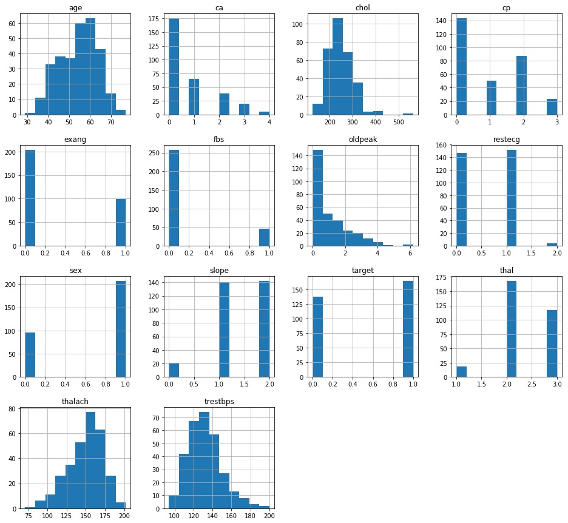

```python
Heart_df.hist(figsize=(16,15))
```

back to top

### 1. Target

```python
HaveDisease = len(Heart_df[Heart_df.target == 0])
NoDisease = len(Heart_df[Heart_df.target == 1])
print("Number of people having heart disease : ",HaveDisease)
print("Number of people having no heart disease : ",NoDisease)
print("Percentage of patients who don't have heart disease: {:.2f}%".format((NoDisease / (len(Heart_df.target))*100)))
print("Percentage of patients who have heart disease: {:.2f}%".format((HaveDisease / (len(Heart_df.target))*100)))
```

```
Number of people having heart disease :  138
Number of people having no heart disease :  165
Percentage of patients who don't have heart disease: 54.46%
Percentage of patients who have heart disease: 45.54%
```

We have a balanced dataset with 45% cases with heart disease and 55% without heart disease.

```
Text(0,0.5,'Frequency')
```

```
Text(0.5,0,'Target')
```

```
Text(0,0.5,'Frequency')
```

```
Text(0.5,0,'sex')
```

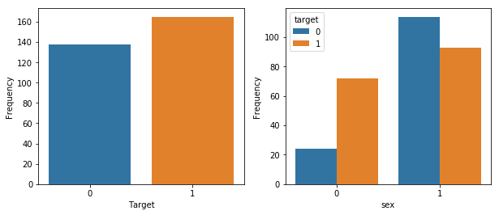

```python
fig,ax=plt.subplots(figsize=(10,4))
plt.subplot(1, 2, 1)
g1=sns.countplot(x="target", data=Heart_df)
g1.set_ylabel('Frequency')
g1.set_xlabel('Target')

plt.subplot(1, 2, 2)
g2=sns.countplot(x='sex',hue='target',data=Heart_df)
g2.set_ylabel('Frequency')
g2.set_xlabel('sex')
```

We see that percentage of having heart disease is more in men than in women.

```
Text(0.5,1,'Cholestoral vs Heart Disease')
```

```
Text(0.5,1,'Thalach vs Heart Disease')
```

```
Text(0.5,1,'Trestbps vs Heart Disease')
```

```
Text(0.5,1,'oldpeak vs Heart Disease')
```

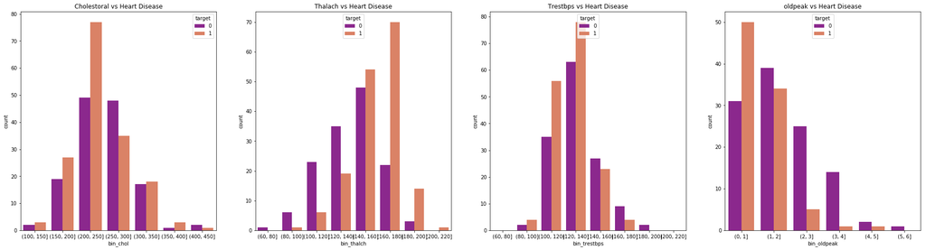

```python
# Target Verses continuous variables

fig,ax=plt.subplots(figsize=(32,8))
plt.subplot(1, 4, 1)
cho_bins = [100,150,200,250,300,350,400,450]
Heart_df['bin_chol']=pd.cut(Heart_df['chol'], bins=cho_bins)
g1=sns.countplot(x='bin_chol',data=Heart_df,hue='target',palette='plasma',linewidth=3)
g1.set_title("Cholestoral vs Heart Disease")

plt.subplot(1, 4, 2)
thal_bins = [60,80,100,120,140,160,180,200,220]
Heart_df['bin_thalch']=pd.cut(Heart_df['thalach'], bins=thal_bins)
g2=sns.countplot(x='bin_thalch',data=Heart_df,hue='target',palette='plasma',linewidth=3)
g2.set_title("Thalach vs Heart Disease")

plt.subplot(1, 4, 3)
trestbps_bins = [60,80,100,120,140,160,180,200,220]
Heart_df['bin_trestbps']=pd.cut(Heart_df['trestbps'], bins=trestbps_bins)
g3=sns.countplot(x='bin_trestbps',data=Heart_df,hue='target',palette='plasma',linewidth=3)
g3.set_title("Trestbps vs Heart Disease")

plt.subplot(1, 4, 4)
oldpeak_bins= [0,1,2,3,4,5,6]
Heart_df['bin_oldpeak']=pd.cut(Heart_df['oldpeak'], bins=oldpeak_bins)
g4=sns.countplot(x='bin_oldpeak',data=Heart_df,hue='target',palette='plasma',linewidth=3)
g4.set_title("oldpeak vs Heart Disease")
plt.show()
```

```
Text(0.5,1,'Thal Vs Target')
```

```
Text(0.5,1,'slope Vs Target')
```

```
Text(0.5,1,'Restecg Vs Target')
```

```
Text(0.5,1,'Ca Vs Target')
```

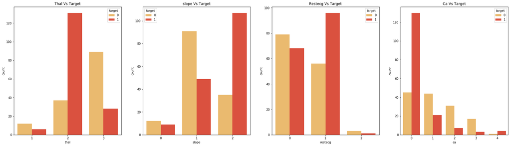

```
 [Text(-1.02657,-0.621419,'No'), Text(0.941019,0.569634,'Yes')],
 [Text(-0.59883,-0.362495,'67.3%'), Text(0.513283,0.31071,'32.7%')])
```

```
(-1.1928357199817012,
 1.1095182005509117,
 -1.1596553778376186,
 1.1028407322779634)
```

```
Text(0.5,1,'Exang')
```

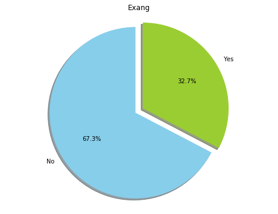

```python
#Target verses categorical variables
# thal, slope , restecg
fig,ax=plt.subplots(figsize=(30,8))


plt.subplot(141)
x1=sns.countplot(x='thal',data=Heart_df,hue='target',palette='YlOrRd',linewidth=3)
x1.set_title('Thal Vs Target')

plt.subplot(142)
x2=sns.countplot(x='slope',data=Heart_df,hue='target',palette='YlOrRd',linewidth=3)
x2.set_title('slope Vs Target')

plt.subplot(143)
x3=sns.countplot(x='restecg',data=Heart_df,hue='target',palette='YlOrRd',linewidth=3)
x3.set_title('Restecg Vs Target')

plt.subplot(144)
x4=sns.countplot(x='ca',data=Heart_df,hue='target',palette='YlOrRd',linewidth=3)
x4.set_title('Ca Vs Target')
plt.show()


plt.figure(figsize=(8,6))
labels = 'No','Yes'
sizes = [len(Heart_df[Heart_df['exang'] == 0]),len(Heart_df[Heart_df['exang'] == 1])]
colors = ['skyblue', 'yellowgreen']
explode = (0.1, 0)  # explode 1st slice

plt.pie(sizes, explode=explode, labels=labels, colors=colors,autopct='%1.1f%%',
        shadow=True, startangle=90)
plt.axis('equal')
plt.title('Exang')
plt.show()
```

```python
pd.crosstab([Heart_df.sex], [Heart_df.target])
ct_sex = pd.crosstab([Heart_df.sex], [Heart_df.target], normalize='index')
ct_sex
pd.crosstab([Heart_df.fbs], [Heart_df.target])
ct_fbs = pd.crosstab([Heart_df.fbs], [Heart_df.target], normalize='index')
ct_fbs
pd.crosstab([Heart_df.restecg], [Heart_df.target])
ct_ecg = pd.crosstab([Heart_df.restecg], [Heart_df.target], normalize='index')
ct_ecg
pd.crosstab([Heart_df.exang], [Heart_df.target])
ct_exang = pd.crosstab([Heart_df.exang], [Heart_df.target], normalize='index')
ct_exang
pd.crosstab([Heart_df.slope], [Heart_df.target])
ct_slope = pd.crosstab([Heart_df.slope], [Heart_df.target], normalize='index')
ct_slope
pd.crosstab([Heart_df.ca], [Heart_df.target])
ct_ca = pd.crosstab([Heart_df.ca], [Heart_df.target], normalize='index')
ct_ca
pd.crosstab([Heart_df.thal], [Heart_df.target])
ct_thal = pd.crosstab([Heart_df.thal], [Heart_df.target], normalize='index')
ct_thal
pd.crosstab([Heart_df.cp], [Heart_df.target])
ct_cp = pd.crosstab([Heart_df.cp], [ Heart_df.target], normalize='index')
ct_cp
```

| target sex | 0 | 1 |
| --- | --- | --- |
| 0 | 24 | 72 |
| 1 | 114 | 93 |

| target sex | 0 | 1 |
| --- | --- | --- |
| 0 | 0.250000 | 0.750000 |
| 1 | 0.550725 | 0.449275 |

| target fbs | 0 | 1 |
| --- | --- | --- |
| 0 | 116 | 142 |
| 1 | 22 | 23 |

| target fbs | 0 | 1 |
| --- | --- | --- |
| 0 | 0.449612 | 0.550388 |
| 1 | 0.488889 | 0.511111 |

| target restecg | 0 | 1 |
| --- | --- | --- |
| 0 | 79 | 68 |
| 1 | 56 | 96 |
| 2 | 3 | 1 |

| target restecg | 0 | 1 |
| --- | --- | --- |
| 0 | 0.537415 | 0.462585 |
| 1 | 0.368421 | 0.631579 |
| 2 | 0.750000 | 0.250000 |

| target exang | 0 | 1 |
| --- | --- | --- |
| 0 | 62 | 142 |
| 1 | 76 | 23 |

| target exang | 0 | 1 |
| --- | --- | --- |
| 0 | 0.303922 | 0.696078 |
| 1 | 0.767677 | 0.232323 |

| target slope | 0 | 1 |
| --- | --- | --- |
| 0 | 12 | 9 |
| 1 | 91 | 49 |
| 2 | 35 | 107 |

| target slope | 0 | 1 |
| --- | --- | --- |
| 0 | 0.571429 | 0.428571 |
| 1 | 0.650000 | 0.350000 |
| 2 | 0.246479 | 0.753521 |

| target ca | 0 | 1 |
| --- | --- | --- |
| 0 | 45 | 130 |
| 1 | 44 | 21 |
| 2 | 31 | 7 |
| 3 | 17 | 3 |
| 4 | 1 | 4 |

| target ca | 0 | 1 |
| --- | --- | --- |
| 0 | 0.257143 | 0.742857 |
| 1 | 0.676923 | 0.323077 |
| 2 | 0.815789 | 0.184211 |
| 3 | 0.850000 | 0.150000 |
| 4 | 0.200000 | 0.800000 |

| target thal | 0 | 1 |
| --- | --- | --- |
| 1 | 12 | 6 |
| 2 | 37 | 131 |
| 3 | 89 | 28 |

| target thal | 0 | 1 |
| --- | --- | --- |
| 1 | 0.666667 | 0.333333 |
| 2 | 0.220238 | 0.779762 |
| 3 | 0.760684 | 0.239316 |

| target cp | 0 | 1 |
| --- | --- | --- |
| 0 | 104 | 39 |
| 1 | 9 | 41 |
| 2 | 18 | 69 |
| 3 | 7 | 16 |

| target cp | 0 | 1 |
| --- | --- | --- |
| 0 | 0.727273 | 0.272727 |
| 1 | 0.180000 | 0.820000 |
| 2 | 0.206897 | 0.793103 |
| 3 | 0.304348 | 0.695652 |

Based on the above analysis we can see that:

### 2. Age

```
array([[<matplotlib.axes._subplots.AxesSubplot object at 0x0000027E83AF94E0>]],
      dtype=object)
```

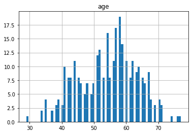

```python
Heart_df.hist("age", bins=75)
```

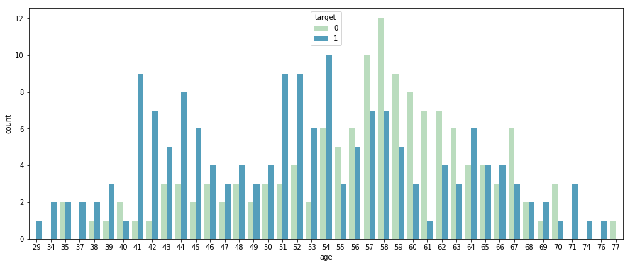

```python
plt.figure(figsize=(15,6))
sns.countplot(x='age',data = Heart_df, hue = 'target',palette='GnBu')
plt.show()
```

```
Text(0.5,1,'Age for all')
```

```
Text(0.5,1,'Age for Target = 0')
```

```
Text(0.5,1,'Age for Target = 1')
```

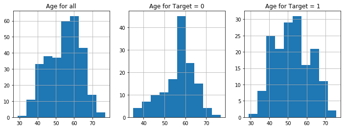

```python
plt.subplot(1,3,1)
Heart_df.age.hist(figsize=(12,4))
plt.title('Age for all')
plt.subplot(1,3,2)
Heart_df[Heart_df.target == 0].age.hist()
plt.title('Age for Target = 0')
plt.subplot(1,3,3)
Heart_df[Heart_df.target == 1].age.hist()
plt.title('Age for Target = 1')
```

```
 There are 6 patients with heart disease compared to 13 patients without it among 19 youngsters
 There are 43 patients with heart disease compared to 90 patients without it among 133 middle aged
 There are 89 patients with heart disease compared to 62 patients without it among 151 eldely aged
```

```
Text(0.5,1,'Heart Disease Frequency for AgeGroup')
```

```
Text(0.5,0,'Agegroups (0-young ages 1-middle ages 2-elderly ages)')
```

```
Text(0,0.5,'Frequency')
```

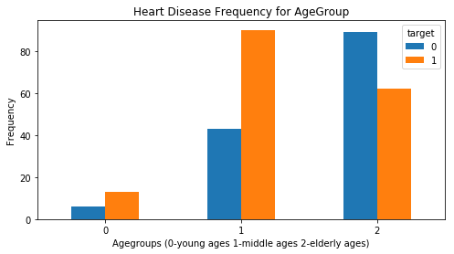

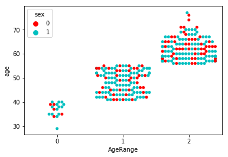

```python
Heart_df['AgeRange']=0

youngAge=Heart_df[(Heart_df.age>=29)&(Heart_df.age<=40)].index
middleAge=Heart_df[(Heart_df.age>40)&(Heart_df.age<=55)].index
elderlyAge=Heart_df[(Heart_df.age>55)].index


#Assigning values to different agerange based on the agegroups
Heart_df.loc[youngAge, 'AgeRange'] = 0
Heart_df.loc[middleAge, 'AgeRange'] = 1
Heart_df.loc[elderlyAge, 'AgeRange'] = 2
#Heart_df['AgeRange'] = Heart_df['AgeRange'].astype(int)

# Target based on the agegroup

#Youngeage
youngeage_0=len(Heart_df[(Heart_df.target==0)&(Heart_df.AgeRange==0)])
youngeage_1=len(Heart_df[(Heart_df.target==1)&(Heart_df.AgeRange==0)])
print(" There are {} patients with heart disease compared to {} patients without it among {} youngsters "
      .format(youngeage_0,youngeage_1,len(youngAge)))

middleage_0=len(Heart_df[(Heart_df.target==0)&(Heart_df.AgeRange==1)])
middleage_1=len(Heart_df[(Heart_df.target==1)&(Heart_df.AgeRange==1)])
print(" There are {} patients with heart disease compared to {} patients without it among {} middle aged "
      .format(middleage_0,middleage_1,len(middleAge)))

elderlyage_0=len(Heart_df[(Heart_df.target==0)&(Heart_df.AgeRange==2)])
elderlyage_1=len(Heart_df[(Heart_df.target==1)&(Heart_df.AgeRange==2)])
print(" There are {} patients with heart disease compared to {} patients without it among {} eldely aged "
      .format(elderlyage_0,elderlyage_1,len(elderlyAge)))


# Plotting the above data
pd.crosstab(Heart_df.AgeRange,Heart_df.target).plot(kind="bar",figsize=(8,4))
plt.title('Heart Disease Frequency for AgeGroup')
plt.xlabel('Agegroups (0-young ages 1-middle ages 2-elderly ages)')
plt.xticks(rotation = 0)
plt.ylabel('Frequency')
plt.show()
sns.swarmplot(x="AgeRange", y="age",hue='sex',
              palette=["r", "c", "y"], data=Heart_df)
```

```
 [Text(0.601643,0.920883,'Disease '), Text(-0.601643,-0.920883,'No Disease')],
 [Text(0.328169,0.5023,'31.6%'), Text(-0.328169,-0.5023,'68.4%')])
```

```
Text(0.5,1,' Youngsters ')
```

```
 [Text(0.579725,0.934836,'Disease '), Text(-0.579725,-0.934836,'No Disease')],
 [Text(0.316214,0.509911,'32.3%'), Text(-0.316214,-0.509911,'67.7%')])
```

```
Text(0.5,1,'Middleagers ')
```

```
 [Text(-0.304912,1.0569,' Disease '), Text(0.304912,-1.0569,'No Disease')],
 [Text(-0.166316,0.576489,'58.9%'), Text(0.166316,-0.576489,'41.1%')])
```

```
Text(0.5,1,' Elderlyagers ')
```

```
Text(0.5,0.98,'Percentage of Heart Disease found in different age groups')
```

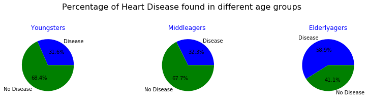

```python
from matplotlib.gridspec import GridSpec

plt.figure(1, figsize=(14,8))
the_grid = GridSpec(3, 3)
colors = ['blue','green']
explode = [0,0]

plt.subplot(the_grid[0, 0], aspect=1, title='Youngsters')
plt.pie([youngeage_0,youngeage_1], explode=explode, labels=['Disease ','No Disease'],
        colors=colors, autopct='%1.1f%%')
plt.title(' Youngsters ',color = 'blue',fontsize = 12)

plt.subplot(the_grid[0, 1], aspect=1, title='Middleagers')
plt.pie([middleage_0,middleage_1], explode=explode, labels=['Disease ','No Disease'],
        colors=colors, autopct='%1.1f%%')
plt.title('Middleagers ',color = 'blue',fontsize = 12)

plt.subplot(the_grid[0, 2], aspect=1, title='Middleagers')
plt.pie([elderlyage_0,elderlyage_1], explode=explode, labels=[' Disease ','No Disease'],
        colors=colors, autopct='%1.1f%%')
plt.title(' Elderlyagers ',color = 'blue',fontsize = 12)

plt.suptitle('Percentage of Heart Disease found in different age groups', fontsize=16)
plt.show()
```

### Analysis:

- The minimum age of the patient is 29 and the maximum age is 77
- For Age Analysis,the ages are divided into the elderly,middle-aged, young people.
- The total number of Youngsters, middle agers and elderly agers are 19 , 133 and 151
- There are 6 patients with heart disease compared to 13 patients without it among 19 youngsters
- There are 43 patients with heart disease compared to 90 patients without it among 133 middle aged
- There are 89 patients with heart disease compared to 62 patients without it among 151 eldely aged
- People over the range of 55-65 are more likely to have heart disease.
- Probability of getting heart disease starts to reduce significantly after age of 65.
- Back to Target
- back to top

### 2. Sex

```
<BarContainer object of 2 artists>
```

```
[Text(0,0,'Male'), Text(0,0,'Female')]
```

```
 [Text(-0.922848,-0.598625,'Male'), Text(1.17453,0.761886,'Female')],
 [Text(-0.503372,-0.326522,'68.3%'), Text(0.755058,0.489784,'31.7%')])
```

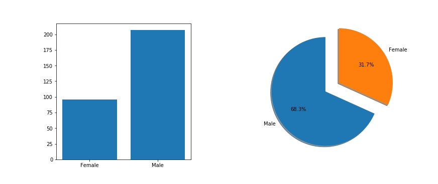

```
There are 96 female and 207 male patients out of 303 patients in total
The percentage of female and male patients are 31.68 and 68.32
```

```python
male_count=len(Heart_df[Heart_df['sex']==1])
female_count=len(Heart_df[Heart_df['sex']==0])

fig, (ax1,ax2) = plt.subplots(1,2,figsize = (12,5),constrained_layout=True)
plt.subplots_adjust(wspace = 0.5)

ax1.bar(Heart_df.sex.unique(),Heart_df.sex.value_counts(),width = 0.8)
ax1.set_xticks(Heart_df.sex.unique())
ax1.set_xticklabels(('Male','Female'))

ax2.pie((male_count,female_count), labels = ('Male','Female'), autopct='%1.1f%%', shadow=True, startangle=90, explode=[0,0.3])
plt.show()

print("There are {} female and {} male patients out of {} patients in total".
      format(female_count,male_count,len(Heart_df.sex)))

print("The percentage of female and male patients are {:.2f} and {:.2f} ".
      format((female_count / (len(Heart_df.sex))*100),(male_count / (len(Heart_df.sex))*100)))
```

```
Text(0.5,1,'Age for males')
```

```
Text(0.5,1,'Age for Target = 0 males')
```

```
Text(0.5,1,'Age for Target = 1 males')
```

```
Text(0.5,1,'Age for females')
```

```
Text(0.5,1,'Age for Target = 0 females')
```

```
Text(0.5,1,'Age for Target = 1 females')
```

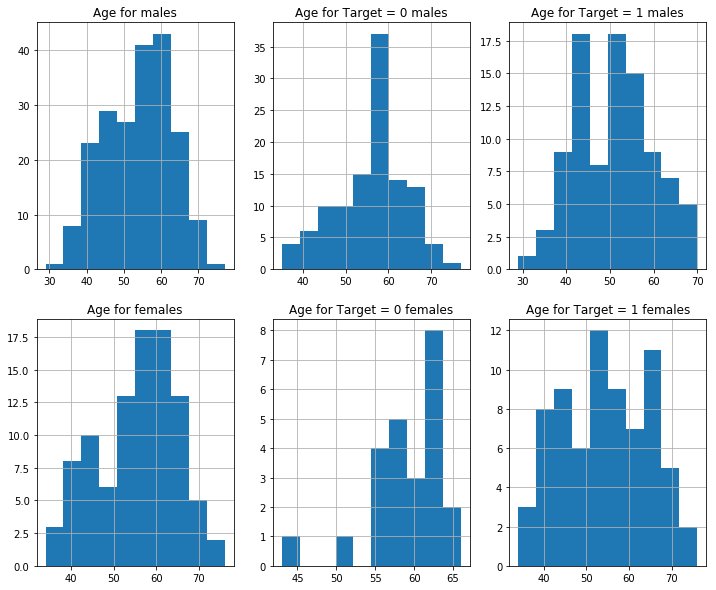

```python
plt.subplot(2,3,1)
Heart_df[Heart_df.sex == 1].age.hist(figsize=(12,10))
plt.title('Age for males')
plt.subplot(2,3,2)
Heart_df[(Heart_df.target == 0) & (Heart_df.sex == 1)].age.hist()
plt.title('Age for Target = 0 males')
plt.subplot(2,3,3)
Heart_df[(Heart_df.target == 1) & (Heart_df.sex == 1)].age.hist()
plt.title('Age for Target = 1 males')

plt.subplot(2,3,4)
Heart_df[Heart_df.sex == 0].age.hist()
plt.title('Age for females')
plt.subplot(2,3,5)
Heart_df[(Heart_df.target == 0) & (Heart_df.sex == 0)].age.hist()
plt.title('Age for Target = 0 females')
plt.subplot(2,3,6)
Heart_df[(Heart_df.target == 1) & (Heart_df.sex == 0)].age.hist()
plt.title('Age for Target = 1 females')
```

```python
data= Heart_df
agerange='AgeRange'
female_young=len(data[(data.AgeRange==0)&(data.sex==0)])
male_young =len(data[(data.AgeRange==0)&(data.sex==1)])

female_middle=len(data[(data.AgeRange==1)&(data.sex==0)])
male_middle =len(data[(data.AgeRange==1)&(data.sex==1)])

female_elderly=len(data[(data.AgeRange==2)&(data.sex==0)])
male_elderly =len(data[(data.AgeRange==2)&(data.sex==1)])

female_young_0=len(data[(data.target==0)&(data.AgeRange==0)&(data.sex==0)])
female_young_1=len(data[(data.target==1)&(data.AgeRange==0)&(data.sex==0)])
male_young_0=len(data[(data.target==0)&(data.AgeRange==0)&(data.sex==1)])
male_young_1=len(data[(data.target==1)&(data.AgeRange==0)&(data.sex==1)])

female_middle_0=len(data[(data.target==0)&(data.AgeRange==1)&(data.sex==0)])
female_middle_1=len(data[(data.target==1)&(data.AgeRange==1)&(data.sex==0)])
male_middle_0=len(data[(data.target==0)&(data.AgeRange==1)&(data.sex==1)])
male_middle_1=len(data[(data.target==1)&(data.AgeRange==1)&(data.sex==1)])

female_elderly_0=len(data[(data.target==0)&(data.AgeRange==2)&(data.sex==0)])
female_elderly_1=len(data[(data.target==1)&(data.AgeRange==2)&(data.sex==0)])
male_elderly_0=len(data[(data.target==0)&(data.AgeRange==2)&(data.sex==1)])
male_elderly_1=len(data[(data.target==1)&(data.AgeRange==2)&(data.sex==1)])


print("** The tabular data of findings of disease among the 303 Patients**")
from tabletext import to_text

results =[["Agegroup", "Female","Male","Female-0","Female-1","Male-0","Male-1"],
["Youngage", female_young, male_young,female_young_0,female_young_1,
 male_young_0, male_young_1],
["Middleage", female_middle, male_middle, female_middle_0,
          female_middle_1, male_middle_0, male_middle_1],
["Elderlyage", female_elderly, male_elderly, female_elderly_0,
          female_elderly_1, female_elderly_0, male_elderly_1]]
print (to_text(results))
```

[output not shown]

```
Text(0.5,1,'chol male')
```

```
Text(0.5,1,'chol Target = 0 for males')
```

```
Text(0.5,1,'chol Target = 1 for males')
```

```
Text(0.5,1,'chol female')
```

```
Text(0.5,1,'chol Target = 0 for females')
```

```
Text(0.5,1,'chol Target = 1 for females')
```

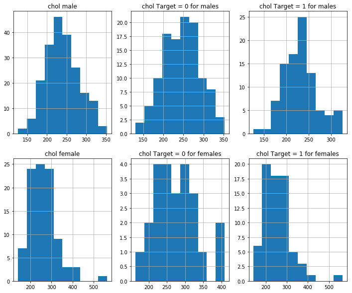

```python
plt.subplot(2,3,1)
Heart_df[Heart_df.sex == 1].chol.hist(figsize=(12,10))
plt.title('chol male')
plt.subplot(2,3,2)
Heart_df[(Heart_df.target == 0) & (Heart_df.sex == 1)].chol.hist()
plt.title('chol Target = 0 for males')
plt.subplot(2,3,3)
Heart_df[(Heart_df.target == 1) & (Heart_df.sex == 1)].chol.hist()
plt.title('chol Target = 1 for males')

plt.subplot(2,3,4)
Heart_df[Heart_df.sex == 0].chol.hist()
plt.title('chol female')
plt.subplot(2,3,5)
Heart_df[(Heart_df.target == 0) & (Heart_df.sex == 0)].chol.hist()
plt.title('chol Target = 0 for females')
plt.subplot(2,3,6)
Heart_df[(Heart_df.target == 1) & (Heart_df.sex == 0)].chol.hist()
plt.title('chol Target = 1 for females')
```

```
Text(0.5,1,'max heart rate male')
```

```
Text(0.5,1,'max heart-rate Target = 0 for males')
```

```
Text(0.5,1,'max heart-rate Target = 1 for males')
```

```
Text(0.5,1,'max heart rate female')
```

```
Text(0.5,1,'max heart-rate Target = 0 for females')
```

```
Text(0.5,1,'max heart-rate Target = 1 for females')
```

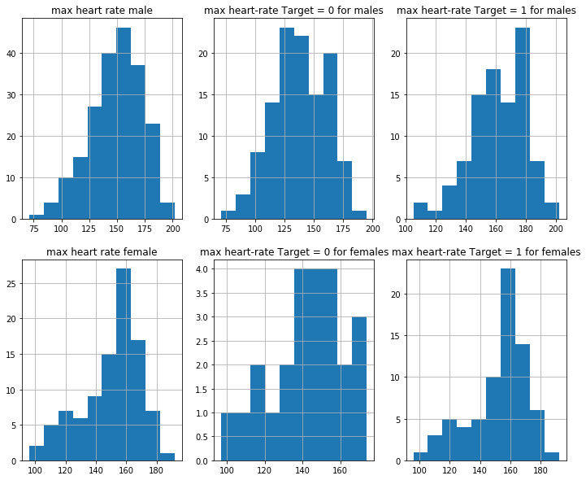

```python
plt.subplot(2,3,1)
Heart_df[Heart_df.sex == 1].thalach.hist(figsize=(12,10))
plt.title('max heart rate male')
plt.subplot(2,3,2)
Heart_df[(Heart_df.target == 0) & (Heart_df.sex == 1)].thalach.hist()
plt.title('max heart-rate Target = 0 for males')
plt.subplot(2,3,3)
Heart_df[(Heart_df.target == 1) & (Heart_df.sex == 1)].thalach.hist()
plt.title('max heart-rate Target = 1 for males')

plt.subplot(2,3,4)
Heart_df[Heart_df.sex == 0].thalach.hist()
plt.title('max heart rate female')
plt.subplot(2,3,5)
Heart_df[(Heart_df.target == 0) & (Heart_df.sex == 0)].thalach.hist()
plt.title('max heart-rate Target = 0 for females')
plt.subplot(2,3,6)
Heart_df[(Heart_df.target == 1) & (Heart_df.sex == 0)].thalach.hist()
plt.title('max heart-rate Target = 1 for females')
```

```
Text(0.5,1,'oldpeak male')
```

```
Text(0.5,1,'oldpeak Target = 0 for males')
```

```
Text(0.5,1,'oldpeak Target = 1 for males')
```

```
Text(0.5,1,'oldpeak female')
```

```
Text(0.5,1,'oldpeak Target = 0 for females')
```

```
Text(0.5,1,'oldpeak Target = 1 for females')
```

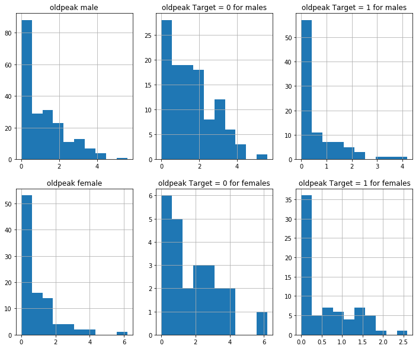

```python
plt.subplot(2,3,1)
Heart_df[Heart_df.sex == 1].oldpeak.hist(figsize=(12,10))
plt.title('oldpeak male')
plt.subplot(2,3,2)
Heart_df[(Heart_df.target == 0) & (Heart_df.sex == 1)].oldpeak.hist()
plt.title('oldpeak Target = 0 for males')
plt.subplot(2,3,3)
Heart_df[(Heart_df.target == 1) & (Heart_df.sex == 1)].oldpeak.hist()
plt.title('oldpeak Target = 1 for males')

plt.subplot(2,3,4)
Heart_df[Heart_df.sex == 0].oldpeak.hist()
plt.title('oldpeak female')
plt.subplot(2,3,5)
Heart_df[(Heart_df.target == 0) & (Heart_df.sex == 0)].oldpeak.hist()
plt.title('oldpeak Target = 0 for females')
plt.subplot(2,3,6)
Heart_df[(Heart_df.target == 1) & (Heart_df.sex == 0)].oldpeak.hist()
plt.title('oldpeak Target = 1 for females')
```

### 4. Chest Pain Type

```
 [Text(-0.0968181,-1.09573,'Chest Pain Type:0'),
  Text(1.03624,0.369068,'Chest Pain Type:1'),
  Text(-0.209703,1.07983,'Chest Pain Type:2'),
  Text(-1.06887,0.259839,'Chest Pain Type:3')],
 [Text(-0.0528099,-0.597671,'47.2%'),
  Text(0.565221,0.20131,'16.5%'),
  Text(-0.114384,0.588996,'28.7%'),
  Text(-0.58302,0.14173,'7.6%')])
```

```
(-1.1007488061044435,
 1.1157249281933113,
 -1.1195424947090913,
 1.1118696412623554)
```

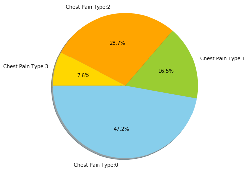

```python
plt.figure(figsize=(8,6))


labels = 'Chest Pain Type:0','Chest Pain Type:1','Chest Pain Type:2','Chest Pain Type:3'
sizes = [len(Heart_df[Heart_df['cp'] == 0]),len(Heart_df[Heart_df['cp'] == 1]),
         len(Heart_df[Heart_df['cp'] == 2]),
         len(Heart_df[Heart_df['cp'] == 3])]
colors = ['skyblue', 'yellowgreen','orange','gold']
explode = (0, 0,0,0)  # explode 1st slice

# Plot
plt.pie(sizes, explode=explode, labels=labels, colors=colors,
autopct='%1.1f%%', shadow=True, startangle=180)

plt.axis('equal')
plt.show()
```

```python
pd.crosstab([Heart_df.cp], [Heart_df.target])
ct_cp = pd.crosstab([Heart_df.cp], [ Heart_df.target], normalize='index')
ct_cp
```

| target cp | 0 | 1 |
| --- | --- | --- |
| 0 | 104 | 39 |
| 1 | 9 | 41 |
| 2 | 18 | 69 |
| 3 | 7 | 16 |

| target cp | 0 | 1 |
| --- | --- | --- |
| 0 | 0.727273 | 0.272727 |
| 1 | 0.180000 | 0.820000 |
| 2 | 0.206897 | 0.793103 |
| 3 | 0.304348 | 0.695652 |

```
Text(0.5,1,'Heart Disease Frequency According To chest pain type')
```

```
Text(0.5,0,'chest pain type - (0-asymptomatic 1-atypical angina 2-non-anginal pain 3-typical angina pain)')
```

```
Text(0,0.5,'Frequency')
```

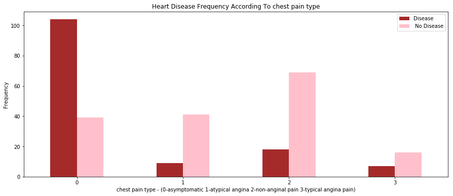

```python
pd.crosstab(Heart_df.cp,data.target).plot(kind="bar",figsize=(15,6),color=['brown','pink' ])
plt.title('Heart Disease Frequency According To chest pain type')
plt.xlabel('chest pain type - (0-asymptomatic 1-atypical angina 2-non-anginal pain 3-typical angina pain)')
plt.xticks(rotation = 0)
plt.legend(["Disease", " No Disease"])
plt.ylabel('Frequency')
plt.show()
```

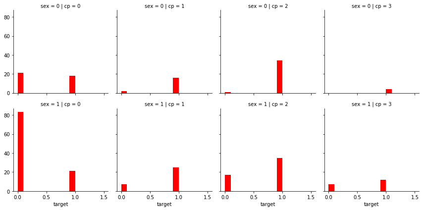

```python
g = sns.FacetGrid(Heart_df, col="cp",  row="sex")
g = g.map(plt.hist, "target",  color="r")
```

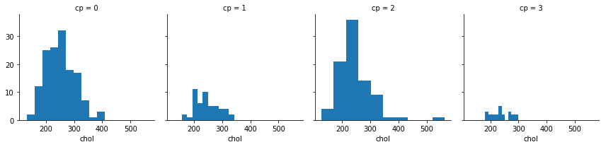

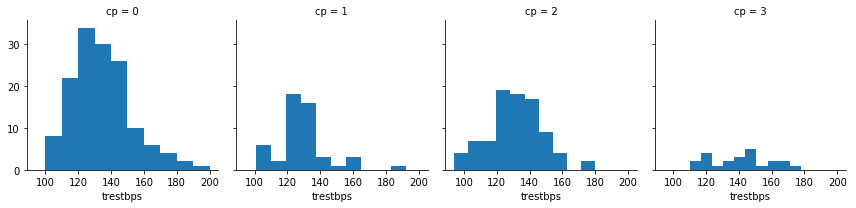

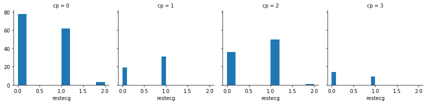

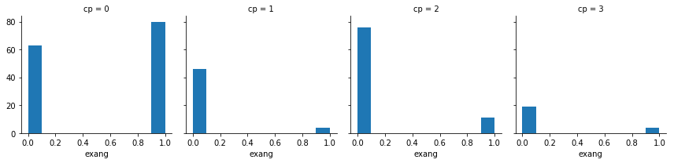

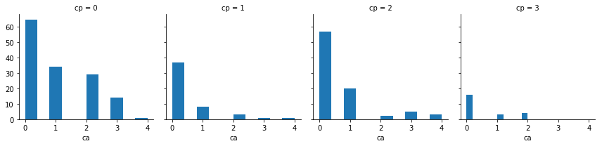

```python
g = sns.FacetGrid(Heart_df, col='cp')
g.map(plt.hist, 'chol', bins=10)

g = sns.FacetGrid(Heart_df, col='cp')
g.map(plt.hist, 'trestbps', bins=10)

g = sns.FacetGrid(Heart_df, col='cp')
g.map(plt.hist, 'restecg', bins=10)

g = sns.FacetGrid(Heart_df, col='cp')
g.map(plt.hist, 'exang', bins=10)

g = sns.FacetGrid(Heart_df, col='cp')
g.map(plt.hist, 'ca', bins=10)
```

### 5. Fasting blood sugar

```
Text(0.5,1,'Fbs Vs Target')
```

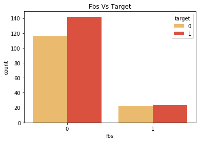

```python
sns.countplot(x='fbs',data=Heart_df,hue='target',palette='YlOrRd',linewidth=3)
plt.title('Fbs Vs Target')
```

```
Text(0.5,1,'Fbs Type vs Target based on gender ')
```

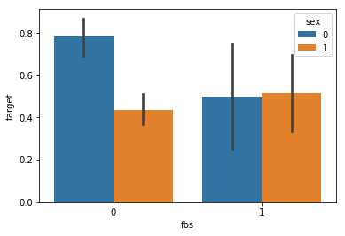

```python
sns.barplot(x = 'fbs', y = 'target', hue = 'sex', data=Heart_df)
ax.set_title('Fbs Type vs Target based on gender ')
```

```
 [Text(0.522475,-1.08029,'fbs < 120 mg/dl'),
  Text(-0.522475,1.08029,'fbs > 120 mg/dl')],
 [Text(0.304777,-0.630167,'64.3%'), Text(-0.304777,0.630167,'35.7%')])
```

```
(-1.1485198887728463,
 1.1610460480603297,
 -1.207921501000533,
 1.2147056496185078)
```

```
Text(0.5,1,' cp-0 ')
```

```
 [Text(1.04729,-0.585811,'fbs < 120 mg/dl'),
  Text(-1.04729,0.585811,'fbs > 120 mg/dl')],
 [Text(0.610922,-0.341723,'83.8%'), Text(-0.610922,0.341723,'16.2%')])
```

```
(-1.1962658204990206,
 1.2015430275971661,
 -1.1547741903416047,
 1.0577702664298587)
```

```
Text(0.5,1,' cp-1')
```

```
 [Text(0.842713,-0.854303,'fbs < 120 mg/dl'),
  Text(-0.842713,0.854303,'fbs > 120 mg/dl')],
 [Text(0.491583,-0.498344,'74.8%'), Text(-0.491583,0.498344,'25.2%')])
```

```
(-1.1782087652570923,
 1.197409572677021,
 -1.1986071664089362,
 1.1810753775416876)
```

```
Text(0.5,1,' cp-2')
```

```
 [Text(1.16055,-0.30518,'fbs < 120 mg/dl'),
  Text(-1.16055,0.30518,'fbs > 120 mg/dl')],
 [Text(0.676985,-0.178022,'91.8%'), Text(-0.676985,0.178022,'8.2%')])
```

```
(-1.2067382058279927,
 1.2138359860401209,
 -1.1331248556517188,
 1.0777787021840213)
```

```
Text(0.5,1,' cp-3')
```

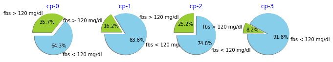

```python
plt.figure(1, figsize=(10,8))
the_grid = GridSpec(4, 4)

labels = 'fbs < 120 mg/dl','fbs > 120 mg/dl'
sizes = [len(Heart_df[Heart_df['fbs'] == 0]),len(Heart_df[Heart_df['cp'] == 0])]
colors = ['skyblue', 'yellowgreen','orange','gold']
explode = (0.1, 0.1)  # explode 1st slice

plt.subplot(the_grid[0, 0], aspect=1, title='cp-0')
plt.pie(sizes, explode=explode, labels=labels, colors=colors,autopct='%1.1f%%',
        shadow=True, startangle=180)
plt.axis('equal')
plt.title(' cp-0 ',color = 'blue',fontsize = 12)

sizes = [len(Heart_df[Heart_df['fbs'] == 0]),len(Heart_df[Heart_df['cp'] == 1])]
plt.subplot(the_grid[0, 1], aspect=1, title='cp-1')
plt.pie(sizes, explode=explode, labels=labels, colors=colors,autopct='%1.1f%%',
        shadow=True, startangle=180)
plt.axis('equal')
plt.title(' cp-1' ,color = 'blue',fontsize = 12)

sizes = [len(Heart_df[Heart_df['fbs'] == 0]),len(Heart_df[Heart_df['cp'] == 2])]
plt.subplot(the_grid[0, 2], aspect=1, title='cp-2')
plt.pie(sizes, explode=explode, labels=labels, colors=colors,autopct='%1.1f%%',
        shadow=True, startangle=180)
plt.axis('equal')
plt.title(' cp-2' ,color = 'blue',fontsize = 12)

sizes = [len(Heart_df[Heart_df['fbs'] == 0]),len(Heart_df[Heart_df['cp'] == 3])]
plt.subplot(the_grid[0, 3], aspect=1, title='cp-3')
plt.pie(sizes, explode=explode, labels=labels, colors=colors,autopct='%1.1f%%',
        shadow=True, startangle=180)
plt.axis('equal')
plt.title(' cp-3'  ,color = 'blue' ,fontsize = 12)

plt.show()
```

```python
pd.crosstab([ Heart_df[Heart_df.sex==0].fbs], [ Heart_df[Heart_df.sex==0].target], normalize='index')
pd.crosstab([ Heart_df[Heart_df.sex==1].fbs], [ Heart_df[Heart_df.sex==1].target], normalize='index')
```

| target fbs | 0 | 1 |
| --- | --- | --- |
| 0 | 0.214286 | 0.785714 |
| 1 | 0.500000 | 0.500000 |

| target fbs | 0 | 1 |
| --- | --- | --- |
| 0 | 0.563218 | 0.436782 |
| 1 | 0.484848 | 0.515152 |

### 6. Maximum heart rate achieved (thalach)

```
Text(0.5,0,'Thalach')
```

```
Text(0,0.5,'Count')
```

```
Text(0.5,1,'Thalach Counts')
```

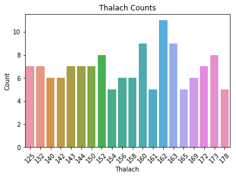

```python
sns.barplot(x=Heart_df.thalach.value_counts()[:20].index,y=Heart_df.thalach.value_counts()[:20].values)
plt.xlabel('Thalach')
plt.ylabel('Count')
plt.title('Thalach Counts')
plt.xticks(rotation=45)
plt.show()
```

```python
age_unique=sorted(Heart_df.age.unique())
age_thalach_values=Heart_df.groupby('age')['thalach'].count().values
mean_thalach=[]
for i,age in enumerate(age_unique):
    mean_thalach.append(sum(Heart_df[Heart_df['age']==age].thalach)/age_thalach_values[i])
```

```
Text(0.5,0,'Age')
```

```
Text(0,0.5,'Thalach')
```

```
Text(0.5,1,'Age vs Thalach')
```

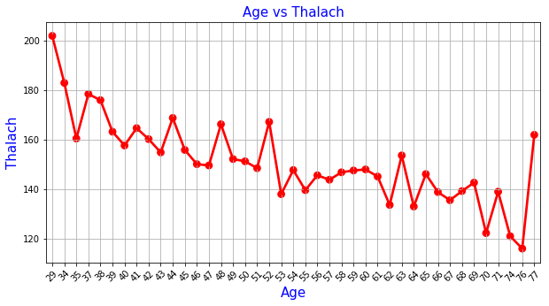

```python
plt.figure(figsize=(10,5))
sns.pointplot(x=age_unique,y=mean_thalach,color='red',alpha=0.8)
plt.xlabel('Age',fontsize = 15,color='blue')
plt.xticks(rotation=45)
plt.ylabel('Thalach',fontsize = 15,color='blue')
plt.title('Age vs Thalach',fontsize = 15,color='blue')
plt.grid()
plt.show()
```

We can see that the maximum heart rate achieved decreases as age increases.

- Back to Target
- back to top